# Risk Factor Analysis

## Outcome Variable

**Outcome Variable:** haz

## Predictor Variables

**Intervention Variable:** single

**Adjustment Set:**

unadjusted

## Stratifying Variables

The analysis was stratified on these variable(s):

- agecat
- studyid
- country

## Data Summary

| agecat | studyid | country | single | n_cell | n |
| --- | --- | --- | --- | --- | --- |
| Birth | COHORTS | GUATEMALA | 0 | 719 | 767 |
| Birth | COHORTS | GUATEMALA | 1 | 48 | 767 |
| Birth | COHORTS | INDIA | 0 | 4771 | 4778 |
| Birth | COHORTS | INDIA | 1 | 7 | 4778 |
| Birth | COHORTS | PHILIPPINES | 0 | 2936 | 3010 |
| Birth | COHORTS | PHILIPPINES | 1 | 74 | 3010 |
| Birth | JiVitA-4 | BANGLADESH | 0 | 2814 | 2819 |
| Birth | JiVitA-4 | BANGLADESH | 1 | 5 | 2819 |
| Birth | MAL-ED | BANGLADESH | 0 | 231 | 231 |
| Birth | MAL-ED | BANGLADESH | 1 | 0 | 231 |
| Birth | MAL-ED | BRAZIL | 0 | 57 | 65 |
| Birth | MAL-ED | BRAZIL | 1 | 8 | 65 |
| Birth | MAL-ED | INDIA | 0 | 47 | 47 |
| Birth | MAL-ED | INDIA | 1 | 0 | 47 |
| Birth | MAL-ED | NEPAL | 0 | 27 | 27 |
| Birth | MAL-ED | NEPAL | 1 | 0 | 27 |
| Birth | MAL-ED | PERU | 0 | 209 | 233 |
| Birth | MAL-ED | PERU | 1 | 24 | 233 |
| Birth | MAL-ED | SOUTH AFRICA | 0 | 63 | 123 |
| Birth | MAL-ED | SOUTH AFRICA | 1 | 60 | 123 |
| Birth | MAL-ED | TANZANIA, UNITED REPUBLIC OF | 0 | 122 | 125 |
| Birth | MAL-ED | TANZANIA, UNITED REPUBLIC OF | 1 | 3 | 125 |
| Birth | PROBIT | BELARUS | 0 | 13351 | 13893 |
| Birth | PROBIT | BELARUS | 1 | 542 | 13893 |
| Birth | ZVITAMBO | ZIMBABWE | 0 | 12942 | 13817 |
| Birth | ZVITAMBO | ZIMBABWE | 1 | 875 | 13817 |
| 6 months | COHORTS | GUATEMALA | 0 | 826 | 893 |
| 6 months | COHORTS | GUATEMALA | 1 | 67 | 893 |
| 6 months | COHORTS | INDIA | 0 | 4962 | 4971 |
| 6 months | COHORTS | INDIA | 1 | 9 | 4971 |

[output cut: 54 more lines]

The following strata were considered:

- agecat: 24 months, studyid: COHORTS, country: GUATEMALA
- agecat: 24 months, studyid: COHORTS, country: INDIA
- agecat: 24 months, studyid: COHORTS, country: PHILIPPINES
- agecat: 24 months, studyid: JiVitA-4, country: BANGLADESH
- agecat: 24 months, studyid: MAL-ED, country: BANGLADESH
- agecat: 24 months, studyid: MAL-ED, country: BRAZIL
- agecat: 24 months, studyid: MAL-ED, country: INDIA
- agecat: 24 months, studyid: MAL-ED, country: NEPAL
- agecat: 24 months, studyid: MAL-ED, country: PERU
- agecat: 24 months, studyid: MAL-ED, country: SOUTH AFRICA
- agecat: 24 months, studyid: MAL-ED, country: TANZANIA, UNITED REPUBLIC OF
- agecat: 24 months, studyid: PROBIT, country: BELARUS
- agecat: 24 months, studyid: TanzaniaChild2, country: TANZANIA, UNITED REPUBLIC OF
- agecat: 24 months, studyid: ZVITAMBO, country: ZIMBABWE
- agecat: 6 months, studyid: COHORTS, country: GUATEMALA
- agecat: 6 months, studyid: COHORTS, country: INDIA
- agecat: 6 months, studyid: COHORTS, country: PHILIPPINES
- agecat: 6 months, studyid: Guatemala BSC, country: GUATEMALA
- agecat: 6 months, studyid: JiVitA-4, country: BANGLADESH
- agecat: 6 months, studyid: MAL-ED, country: BANGLADESH
- agecat: 6 months, studyid: MAL-ED, country: BRAZIL
- agecat: 6 months, studyid: MAL-ED, country: INDIA
- agecat: 6 months, studyid: MAL-ED, country: NEPAL
- agecat: 6 months, studyid: MAL-ED, country: PERU
- agecat: 6 months, studyid: MAL-ED, country: SOUTH AFRICA
- agecat: 6 months, studyid: MAL-ED, country: TANZANIA, UNITED REPUBLIC OF
- agecat: 6 months, studyid: PROBIT, country: BELARUS
- agecat: 6 months, studyid: TanzaniaChild2, country: TANZANIA, UNITED REPUBLIC OF
- agecat: 6 months, studyid: ZVITAMBO, country: ZIMBABWE
- agecat: Birth, studyid: COHORTS, country: GUATEMALA
- agecat: Birth, studyid: COHORTS, country: INDIA
- agecat: Birth, studyid: COHORTS, country: PHILIPPINES
- agecat: Birth, studyid: JiVitA-4, country: BANGLADESH
- agecat: Birth, studyid: MAL-ED, country: BANGLADESH
- agecat: Birth, studyid: MAL-ED, country: BRAZIL
- agecat: Birth, studyid: MAL-ED, country: INDIA
- agecat: Birth, studyid: MAL-ED, country: NEPAL
- agecat: Birth, studyid: MAL-ED, country: PERU
- agecat: Birth, studyid: MAL-ED, country: SOUTH AFRICA
- agecat: Birth, studyid: MAL-ED, country: TANZANIA, UNITED REPUBLIC OF
- agecat: Birth, studyid: PROBIT, country: BELARUS
- agecat: Birth, studyid: ZVITAMBO, country: ZIMBABWE

### Dropped Strata

Some strata were dropped due to rare outcomes:

- agecat: Birth, studyid: MAL-ED, country: BANGLADESH
- agecat: Birth, studyid: MAL-ED, country: INDIA
- agecat: Birth, studyid: MAL-ED, country: NEPAL
- agecat: Birth, studyid: MAL-ED, country: TANZANIA, UNITED REPUBLIC OF
- agecat: 6 months, studyid: MAL-ED, country: BANGLADESH
- agecat: 6 months, studyid: MAL-ED, country: INDIA
- agecat: 6 months, studyid: MAL-ED, country: NEPAL
- agecat: 24 months, studyid: MAL-ED, country: BANGLADESH
- agecat: 24 months, studyid: MAL-ED, country: INDIA
- agecat: 24 months, studyid: MAL-ED, country: NEPAL
- agecat: 24 months, studyid: TanzaniaChild2, country: TANZANIA, UNITED REPUBLIC OF

## Methods Detail

We’re interested in the causal parameters $E[Y_a]$ for all values of $a \in \mathcal{A}$. These parameters represent the mean outcome if, possibly contrary to fact, we intervened to set all units to have $A=a$. Under the randomization and positivity assumptions, these are identified by the statistical parameters $\psi_a=E_W[E_{Y|A,W}(Y|A=a,W)]$. In addition, we’re interested in the mean of $Y$, $E[Y]$ under no intervention (the observed mean). We will estimate these parameters by using SuperLearner to fit the relevant likelihood factors – $E_{Y|A,W}(Y|A=a,W)$ and $p(A=a|W)$, and then updating our likelihood fit using a joint TMLE.

For unadjusted analyses ($W=\{\}$), initial likelihoods were estimated using Lrnr_glm to estimate the simple $E(Y|A)$ and Lrnr_mean to estimate $p(A)$. For adjusted analyses, a small library containing Lrnr_glmnet, Lrnr_xgboost, and Lrnr_mean was used.

Having estimated these parameters, we will then use the delta method to estimate relative risks and attributable risks relative to a prespecified baseline level of $A$.

# Results Detail

## Results Plots

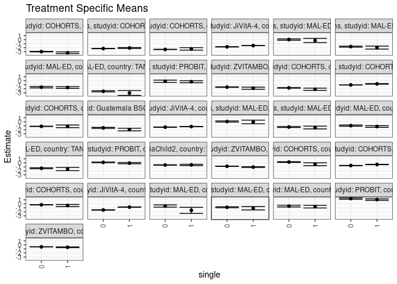

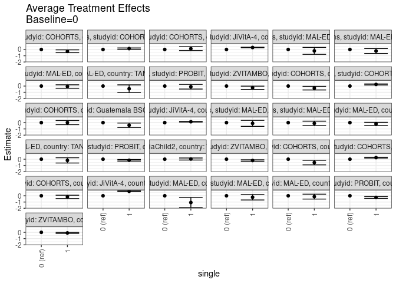

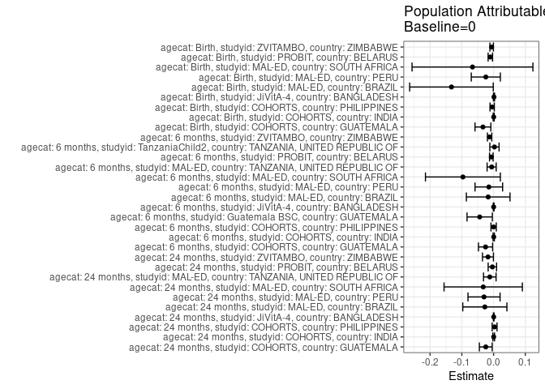

## Results Table

### Parameter: TSM

| agecat | studyid | country | intervention_level | baseline_level | estimate | ci_lower | ci_upper |
| --- | --- | --- | --- | --- | --- | --- | --- |
| Birth | COHORTS | GUATEMALA | 0 | NA | 0.1846871 | 0.0945983 | 0.2747758 |
| Birth | COHORTS | GUATEMALA | 1 | NA | -0.3516667 | -0.7107876 | 0.0074543 |
| Birth | COHORTS | INDIA | 0 | NA | -0.6778139 | -0.7115208 | -0.6441070 |
| Birth | COHORTS | INDIA | 1 | NA | -0.4242857 | -0.4784569 | -0.3701145 |
| Birth | COHORTS | PHILIPPINES | 0 | NA | -0.2421117 | -0.2816143 | -0.2026092 |
| Birth | COHORTS | PHILIPPINES | 1 | NA | -0.4228378 | -0.6883020 | -0.1573737 |
| Birth | JiVitA-4 | BANGLADESH | 0 | NA | -1.5248721 | -1.5752417 | -1.4745025 |
| Birth | JiVitA-4 | BANGLADESH | 1 | NA | -0.8080000 | -0.8384743 | -0.7775257 |
| Birth | MAL-ED | BRAZIL | 0 | NA | -0.5433333 | -0.8229128 | -0.2637539 |
| Birth | MAL-ED | BRAZIL | 1 | NA | -1.6212500 | -2.3756597 | -0.8668403 |
| Birth | MAL-ED | PERU | 0 | NA | -0.8583254 | -0.9795460 | -0.7371047 |
| Birth | MAL-ED | PERU | 1 | NA | -1.0958333 | -1.5138107 | -0.6778560 |
| Birth | MAL-ED | SOUTH AFRICA | 0 | NA | -0.5652381 | -0.7793278 | -0.3511483 |
| Birth | MAL-ED | SOUTH AFRICA | 1 | NA | -0.7015000 | -1.0267622 | -0.3762378 |
| Birth | PROBIT | BELARUS | 0 | NA | 1.3217287 | 1.1610845 | 1.4823729 |
| Birth | PROBIT | BELARUS | 1 | NA | 1.0580443 | 0.8734598 | 1.2426288 |
| Birth | ZVITAMBO | ZIMBABWE | 0 | NA | -0.4946724 | -0.5158678 | -0.4734769 |
| Birth | ZVITAMBO | ZIMBABWE | 1 | NA | -0.5911771 | -0.6755957 | -0.5067586 |
| 6 months | COHORTS | GUATEMALA | 0 | NA | -1.7836199 | -1.8568602 | -1.7103795 |
| 6 months | COHORTS | GUATEMALA | 1 | NA | -2.1211940 | -2.3989115 | -1.8434765 |
| 6 months | COHORTS | INDIA | 0 | NA | -1.0423478 | -1.0757913 | -1.0089044 |
| 6 months | COHORTS | INDIA | 1 | NA | -0.7833333 | -0.8545896 | -0.7120771 |
| 6 months | COHORTS | PHILIPPINES | 0 | NA | -1.1415798 | -1.1840577 | -1.0991018 |
| 6 months | COHORTS | PHILIPPINES | 1 | NA | -1.1361765 | -1.4629462 | -0.8094067 |
| 6 months | Guatemala BSC | GUATEMALA | 0 | NA | -1.5186358 | -1.6410623 | -1.3962092 |
| 6 months | Guatemala BSC | GUATEMALA | 1 | NA | -1.9370115 | -2.2670985 | -1.6069245 |
| 6 months | JiVitA-4 | BANGLADESH | 0 | NA | -1.3443862 | -1.3825869 | -1.3061854 |
| 6 months | JiVitA-4 | BANGLADESH | 1 | NA | -1.1993750 | -1.2225095 | -1.1762405 |
| 6 months | MAL-ED | BRAZIL | 0 | NA | 0.0645531 | -0.0851990 | 0.2143052 |
| 6 months | MAL-ED | BRAZIL | 1 | NA | -0.0537222 | -0.5070021 | 0.3995576 |
| 6 months | MAL-ED | PERU | 0 | NA | -1.3086771 | -1.4222446 | -1.1951096 |
| 6 months | MAL-ED | PERU | 1 | NA | -1.4326768 | -1.7713001 | -1.0940534 |
| 6 months | MAL-ED | SOUTH AFRICA | 0 | NA | -0.9666667 | -1.1189584 | -0.8143750 |
| 6 months | MAL-ED | SOUTH AFRICA | 1 | NA | -1.1820175 | -1.3941062 | -0.9699289 |
| 6 months | MAL-ED | TANZANIA, UNITED REPUBLIC OF | 0 | NA | -1.3626290 | -1.4879351 | -1.2373229 |
| 6 months | MAL-ED | TANZANIA, UNITED REPUBLIC OF | 1 | NA | -1.5514583 | -1.9539746 | -1.1489420 |
| 6 months | PROBIT | BELARUS | 0 | NA | 0.1051661 | 0.0137220 | 0.1966103 |
| 6 months | PROBIT | BELARUS | 1 | NA | -0.0702955 | -0.2301528 | 0.0895618 |
| 6 months | TanzaniaChild2 | TANZANIA, UNITED REPUBLIC OF | 0 | NA | -0.5484818 | -0.6001349 | -0.4968287 |
| 6 months | TanzaniaChild2 | TANZANIA, UNITED REPUBLIC OF | 1 | NA | -0.5178371 | -0.6741242 | -0.3615500 |
| 6 months | ZVITAMBO | ZIMBABWE | 0 | NA | -0.8552031 | -0.8814854 | -0.8289208 |
| 6 months | ZVITAMBO | ZIMBABWE | 1 | NA | -1.0671735 | -1.1784851 | -0.9558618 |
| 24 months | COHORTS | GUATEMALA | 0 | NA | -2.9714843 | -3.0407617 | -2.9022069 |
| 24 months | COHORTS | GUATEMALA | 1 | NA | -3.2567816 | -3.4728494 | -3.0407138 |
| 24 months | COHORTS | INDIA | 0 | NA | -2.2134909 | -2.2535699 | -2.1734120 |
| 24 months | COHORTS | INDIA | 1 | NA | -2.0688889 | -2.1675727 | -1.9702051 |
| 24 months | COHORTS | PHILIPPINES | 0 | NA | -2.4239711 | -2.4697243 | -2.3782180 |
| 24 months | COHORTS | PHILIPPINES | 1 | NA | -2.2925424 | -2.5949988 | -1.9900860 |
| 24 months | JiVitA-4 | BANGLADESH | 0 | NA | -1.7815365 | -1.8179487 | -1.7451244 |
| 24 months | JiVitA-4 | BANGLADESH | 1 | NA | -1.4650000 | -1.4755957 | -1.4544043 |
| 24 months | MAL-ED | BRAZIL | 0 | NA | 0.0336374 | -0.1436726 | 0.2109474 |
| 24 months | MAL-ED | BRAZIL | 1 | NA | -0.1878571 | -0.7110349 | 0.3353206 |
| 24 months | MAL-ED | PERU | 0 | NA | -1.7223390 | -1.8494076 | -1.5952705 |
| 24 months | MAL-ED | PERU | 1 | NA | -1.9646000 | -2.3400009 | -1.5891991 |
| 24 months | MAL-ED | SOUTH AFRICA | 0 | NA | -1.6123664 | -1.7826044 | -1.4421284 |
| 24 months | MAL-ED | SOUTH AFRICA | 1 | NA | -1.6850857 | -1.8999715 | -1.4701999 |
| 24 months | MAL-ED | TANZANIA, UNITED REPUBLIC OF | 0 | NA | -2.6336298 | -2.7712599 | -2.4959997 |
| 24 months | MAL-ED | TANZANIA, UNITED REPUBLIC OF | 1 | NA | -3.0591667 | -3.6621048 | -2.4562285 |
| 24 months | PROBIT | BELARUS | 0 | NA | -0.1404374 | -0.4312384 | 0.1503635 |
| 24 months | PROBIT | BELARUS | 1 | NA | -0.2476207 | -0.4938166 | -0.0014248 |
| 24 months | ZVITAMBO | ZIMBABWE | 0 | NA | -1.5857567 | -1.6437344 | -1.5277790 |
| 24 months | ZVITAMBO | ZIMBABWE | 1 | NA | -1.8643269 | -2.1246428 | -1.6040111 |

### Parameter: E(Y)

| agecat | studyid | country | intervention_level | baseline_level | estimate | ci_lower | ci_upper |
| --- | --- | --- | --- | --- | --- | --- | --- |
| Birth | COHORTS | GUATEMALA | NA | NA | 0.1511213 | 0.0632481 | 0.2389944 |
| Birth | COHORTS | INDIA | NA | NA | -0.6774424 | -0.7103357 | -0.6445492 |
| Birth | COHORTS | PHILIPPINES | NA | NA | -0.2465548 | -0.2856502 | -0.2074594 |
| Birth | JiVitA-4 | BANGLADESH | NA | NA | -1.5236006 | -1.5727441 | -1.4744571 |
| Birth | MAL-ED | BRAZIL | NA | NA | -0.6760000 | -0.9521457 | -0.3998543 |
| Birth | MAL-ED | PERU | NA | NA | -0.8827897 | -1.0001058 | -0.7654736 |
| Birth | MAL-ED | SOUTH AFRICA | NA | NA | -0.6317073 | -0.8249555 | -0.4384591 |
| Birth | PROBIT | BELARUS | NA | NA | 1.3114417 | 1.1524752 | 1.4704082 |
| Birth | ZVITAMBO | ZIMBABWE | NA | NA | -0.5007838 | -0.5213479 | -0.4802197 |
| 6 months | COHORTS | GUATEMALA | NA | NA | -1.8089474 | -1.8800645 | -1.7378303 |
| 6 months | COHORTS | INDIA | NA | NA | -1.0418789 | -1.0745363 | -1.0092215 |
| 6 months | COHORTS | PHILIPPINES | NA | NA | -1.1414425 | -1.1836656 | -1.0992193 |
| 6 months | Guatemala BSC | GUATEMALA | NA | NA | -1.5624368 | -1.6783540 | -1.4465196 |
| 6 months | JiVitA-4 | BANGLADESH | NA | NA | -1.3441456 | -1.3814027 | -1.3068885 |
| 6 months | MAL-ED | BRAZIL | NA | NA | 0.0475758 | -0.0963508 | 0.1915023 |
| 6 months | MAL-ED | PERU | NA | NA | -1.3236661 | -1.4316775 | -1.2156546 |
| 6 months | MAL-ED | SOUTH AFRICA | NA | NA | -1.0633202 | -1.1909180 | -0.9357224 |
| 6 months | MAL-ED | TANZANIA, UNITED REPUBLIC OF | NA | NA | -1.3687449 | -1.4907629 | -1.2467270 |
| 6 months | PROBIT | BELARUS | NA | NA | 0.0980074 | 0.0062724 | 0.1897424 |
| 6 months | TanzaniaChild2 | TANZANIA, UNITED REPUBLIC OF | NA | NA | -0.5457721 | -0.5948454 | -0.4966988 |
| 6 months | ZVITAMBO | ZIMBABWE | NA | NA | -0.8677917 | -0.8934036 | -0.8421799 |
| 24 months | COHORTS | GUATEMALA | NA | NA | -2.9960594 | -3.0622330 | -2.9298858 |
| 24 months | COHORTS | INDIA | NA | NA | -2.2131442 | -2.2522996 | -2.1739887 |
| 24 months | COHORTS | PHILIPPINES | NA | NA | -2.4207616 | -2.4660144 | -2.3755087 |
| 24 months | JiVitA-4 | BANGLADESH | NA | NA | -1.7811362 | -1.8166519 | -1.7456205 |
| 24 months | MAL-ED | BRAZIL | NA | NA | 0.0061144 | -0.1625850 | 0.1748138 |
| 24 months | MAL-ED | PERU | NA | NA | -1.7524710 | -1.8736426 | -1.6312994 |
| 24 months | MAL-ED | SOUTH AFRICA | NA | NA | -1.6450595 | -1.7797240 | -1.5103950 |
| 24 months | MAL-ED | TANZANIA, UNITED REPUBLIC OF | NA | NA | -2.6455607 | -2.7807256 | -2.5103959 |
| 24 months | PROBIT | BELARUS | NA | NA | -0.1442891 | -0.4253755 | 0.1367972 |
| 24 months | ZVITAMBO | ZIMBABWE | NA | NA | -1.6034545 | -1.6603071 | -1.5466018 |

### Parameter: ATE

| agecat | studyid | country | intervention_level | baseline_level | estimate | ci_lower | ci_upper |
| --- | --- | --- | --- | --- | --- | --- | --- |
| Birth | COHORTS | GUATEMALA | 0 | 0 | 0.0000000 | 0.0000000 | 0.0000000 |
| Birth | COHORTS | GUATEMALA | 1 | 0 | -0.5363537 | -0.9066021 | -0.1661054 |
| Birth | COHORTS | INDIA | 0 | 0 | 0.0000000 | 0.0000000 | 0.0000000 |
| Birth | COHORTS | INDIA | 1 | 0 | 0.2535282 | 0.1897264 | 0.3173300 |
| Birth | COHORTS | PHILIPPINES | 0 | 0 | 0.0000000 | 0.0000000 | 0.0000000 |
| Birth | COHORTS | PHILIPPINES | 1 | 0 | -0.1807261 | -0.4491133 | 0.0876611 |
| Birth | JiVitA-4 | BANGLADESH | 0 | 0 | 0.0000000 | 0.0000000 | 0.0000000 |
| Birth | JiVitA-4 | BANGLADESH | 1 | 0 | 0.7168721 | 0.6584462 | 0.7752980 |
| Birth | MAL-ED | BRAZIL | 0 | 0 | 0.0000000 | 0.0000000 | 0.0000000 |
| Birth | MAL-ED | BRAZIL | 1 | 0 | -1.0779167 | -1.8824654 | -0.2733679 |
| Birth | MAL-ED | PERU | 0 | 0 | 0.0000000 | 0.0000000 | 0.0000000 |
| Birth | MAL-ED | PERU | 1 | 0 | -0.2375080 | -0.6727085 | 0.1976926 |
| Birth | MAL-ED | SOUTH AFRICA | 0 | 0 | 0.0000000 | 0.0000000 | 0.0000000 |
| Birth | MAL-ED | SOUTH AFRICA | 1 | 0 | -0.1362619 | -0.5256588 | 0.2531350 |
| Birth | PROBIT | BELARUS | 0 | 0 | 0.0000000 | 0.0000000 | 0.0000000 |
| Birth | PROBIT | BELARUS | 1 | 0 | -0.2636844 | -0.4176957 | -0.1096732 |
| Birth | ZVITAMBO | ZIMBABWE | 0 | 0 | 0.0000000 | 0.0000000 | 0.0000000 |
| Birth | ZVITAMBO | ZIMBABWE | 1 | 0 | -0.0965048 | -0.1835435 | -0.0094661 |
| 6 months | COHORTS | GUATEMALA | 0 | 0 | 0.0000000 | 0.0000000 | 0.0000000 |
| 6 months | COHORTS | GUATEMALA | 1 | 0 | -0.3375742 | -0.6247869 | -0.0503614 |
| 6 months | COHORTS | INDIA | 0 | 0 | 0.0000000 | 0.0000000 | 0.0000000 |
| 6 months | COHORTS | INDIA | 1 | 0 | 0.2590145 | 0.1803003 | 0.3377287 |
| 6 months | COHORTS | PHILIPPINES | 0 | 0 | 0.0000000 | 0.0000000 | 0.0000000 |
| 6 months | COHORTS | PHILIPPINES | 1 | 0 | 0.0054033 | -0.3241158 | 0.3349224 |
| 6 months | Guatemala BSC | GUATEMALA | 0 | 0 | 0.0000000 | 0.0000000 | 0.0000000 |
| 6 months | Guatemala BSC | GUATEMALA | 1 | 0 | -0.4183757 | -0.7704350 | -0.0663165 |
| 6 months | JiVitA-4 | BANGLADESH | 0 | 0 | 0.0000000 | 0.0000000 | 0.0000000 |
| 6 months | JiVitA-4 | BANGLADESH | 1 | 0 | 0.1450112 | 0.1006544 | 0.1893679 |
| 6 months | MAL-ED | BRAZIL | 0 | 0 | 0.0000000 | 0.0000000 | 0.0000000 |
| 6 months | MAL-ED | BRAZIL | 1 | 0 | -0.1182753 | -0.5956518 | 0.3591012 |
| 6 months | MAL-ED | PERU | 0 | 0 | 0.0000000 | 0.0000000 | 0.0000000 |
| 6 months | MAL-ED | PERU | 1 | 0 | -0.1239997 | -0.4811598 | 0.2331604 |
| 6 months | MAL-ED | SOUTH AFRICA | 0 | 0 | 0.0000000 | 0.0000000 | 0.0000000 |
| 6 months | MAL-ED | SOUTH AFRICA | 1 | 0 | -0.2153509 | -0.4764531 | 0.0457513 |
| 6 months | MAL-ED | TANZANIA, UNITED REPUBLIC OF | 0 | 0 | 0.0000000 | 0.0000000 | 0.0000000 |
| 6 months | MAL-ED | TANZANIA, UNITED REPUBLIC OF | 1 | 0 | -0.1888293 | -0.6103990 | 0.2327403 |
| 6 months | PROBIT | BELARUS | 0 | 0 | 0.0000000 | 0.0000000 | 0.0000000 |
| 6 months | PROBIT | BELARUS | 1 | 0 | -0.1754616 | -0.2986548 | -0.0522685 |
| 6 months | TanzaniaChild2 | TANZANIA, UNITED REPUBLIC OF | 0 | 0 | 0.0000000 | 0.0000000 | 0.0000000 |
| 6 months | TanzaniaChild2 | TANZANIA, UNITED REPUBLIC OF | 1 | 0 | 0.0306448 | -0.1339569 | 0.1952464 |
| 6 months | ZVITAMBO | ZIMBABWE | 0 | 0 | 0.0000000 | 0.0000000 | 0.0000000 |
| 6 months | ZVITAMBO | ZIMBABWE | 1 | 0 | -0.2119704 | -0.3263428 | -0.0975980 |
| 24 months | COHORTS | GUATEMALA | 0 | 0 | 0.0000000 | 0.0000000 | 0.0000000 |
| 24 months | COHORTS | GUATEMALA | 1 | 0 | -0.2852973 | -0.5121997 | -0.0583950 |
| 24 months | COHORTS | INDIA | 0 | 0 | 0.0000000 | 0.0000000 | 0.0000000 |
| 24 months | COHORTS | INDIA | 1 | 0 | 0.1446020 | 0.0380900 | 0.2511141 |
| 24 months | COHORTS | PHILIPPINES | 0 | 0 | 0.0000000 | 0.0000000 | 0.0000000 |
| 24 months | COHORTS | PHILIPPINES | 1 | 0 | 0.1314288 | -0.1744686 | 0.4373262 |
| 24 months | JiVitA-4 | BANGLADESH | 0 | 0 | 0.0000000 | 0.0000000 | 0.0000000 |
| 24 months | JiVitA-4 | BANGLADESH | 1 | 0 | 0.3165365 | 0.2791622 | 0.3539109 |
| 24 months | MAL-ED | BRAZIL | 0 | 0 | 0.0000000 | 0.0000000 | 0.0000000 |
| 24 months | MAL-ED | BRAZIL | 1 | 0 | -0.2214945 | -0.7739018 | 0.3309127 |
| 24 months | MAL-ED | PERU | 0 | 0 | 0.0000000 | 0.0000000 | 0.0000000 |
| 24 months | MAL-ED | PERU | 1 | 0 | -0.2422610 | -0.6385844 | 0.1540625 |
| 24 months | MAL-ED | SOUTH AFRICA | 0 | 0 | 0.0000000 | 0.0000000 | 0.0000000 |
| 24 months | MAL-ED | SOUTH AFRICA | 1 | 0 | -0.0727193 | -0.3468668 | 0.2014283 |
| 24 months | MAL-ED | TANZANIA, UNITED REPUBLIC OF | 0 | 0 | 0.0000000 | 0.0000000 | 0.0000000 |
| 24 months | MAL-ED | TANZANIA, UNITED REPUBLIC OF | 1 | 0 | -0.4255369 | -1.0439837 | 0.1929099 |
| 24 months | PROBIT | BELARUS | 0 | 0 | 0.0000000 | 0.0000000 | 0.0000000 |
| 24 months | PROBIT | BELARUS | 1 | 0 | -0.1071832 | -0.4781078 | 0.2637413 |
| 24 months | ZVITAMBO | ZIMBABWE | 0 | 0 | 0.0000000 | 0.0000000 | 0.0000000 |
| 24 months | ZVITAMBO | ZIMBABWE | 1 | 0 | -0.2785702 | -0.5452644 | -0.0118761 |

### Parameter: PAR

| agecat | studyid | country | intervention_level | baseline_level | estimate | ci_lower | ci_upper |
| --- | --- | --- | --- | --- | --- | --- | --- |
| Birth | COHORTS | GUATEMALA | 0 | NA | -0.0335658 | -0.0584960 | -0.0086356 |
| Birth | COHORTS | INDIA | 0 | NA | 0.0003714 | -0.0012471 | 0.0019900 |
| Birth | COHORTS | PHILIPPINES | 0 | NA | -0.0044431 | -0.0112269 | 0.0023407 |
| Birth | JiVitA-4 | BANGLADESH | 0 | NA | 0.0012715 | -0.0004361 | 0.0029791 |
| Birth | MAL-ED | BRAZIL | 0 | NA | -0.1326667 | -0.2643188 | -0.0010145 |
| Birth | MAL-ED | PERU | 0 | NA | -0.0244643 | -0.0702443 | 0.0213156 |
| Birth | MAL-ED | SOUTH AFRICA | 0 | NA | -0.0664692 | -0.2568030 | 0.1238646 |
| Birth | PROBIT | BELARUS | 0 | NA | -0.0102870 | -0.0171793 | -0.0033947 |
| Birth | ZVITAMBO | ZIMBABWE | 0 | NA | -0.0061114 | -0.0116373 | -0.0005855 |
| 6 months | COHORTS | GUATEMALA | 0 | NA | -0.0253275 | -0.0476528 | -0.0030022 |
| 6 months | COHORTS | INDIA | 0 | NA | 0.0004689 | -0.0015226 | 0.0024605 |
| 6 months | COHORTS | PHILIPPINES | 0 | NA | 0.0001373 | -0.0082362 | 0.0085108 |
| 6 months | Guatemala BSC | GUATEMALA | 0 | NA | -0.0438011 | -0.0836367 | -0.0039654 |
| 6 months | JiVitA-4 | BANGLADESH | 0 | NA | 0.0002406 | -0.0008896 | 0.0013707 |
| 6 months | MAL-ED | BRAZIL | 0 | NA | -0.0169773 | -0.0857316 | 0.0517770 |
| 6 months | MAL-ED | PERU | 0 | NA | -0.0149890 | -0.0584286 | 0.0284507 |
| 6 months | MAL-ED | SOUTH AFRICA | 0 | NA | -0.0966535 | -0.2145820 | 0.0212749 |
| 6 months | MAL-ED | TANZANIA, UNITED REPUBLIC OF | 0 | NA | -0.0061159 | -0.0203947 | 0.0081629 |
| 6 months | PROBIT | BELARUS | 0 | NA | -0.0071587 | -0.0127747 | -0.0015428 |
| 6 months | TanzaniaChild2 | TANZANIA, UNITED REPUBLIC OF | 0 | NA | 0.0027098 | -0.0118501 | 0.0172697 |
| 6 months | ZVITAMBO | ZIMBABWE | 0 | NA | -0.0125887 | -0.0194628 | -0.0057145 |
| 24 months | COHORTS | GUATEMALA | 0 | NA | -0.0245751 | -0.0447346 | -0.0044157 |
| 24 months | COHORTS | INDIA | 0 | NA | 0.0003468 | -0.0023256 | 0.0030192 |
| 24 months | COHORTS | PHILIPPINES | 0 | NA | 0.0032096 | -0.0044806 | 0.0108997 |
| 24 months | JiVitA-4 | BANGLADESH | 0 | NA | 0.0004003 | -0.0005837 | 0.0013844 |
| 24 months | MAL-ED | BRAZIL | 0 | NA | -0.0275230 | -0.0970488 | 0.0420028 |
| 24 months | MAL-ED | PERU | 0 | NA | -0.0301320 | -0.0806559 | 0.0203919 |
| 24 months | MAL-ED | SOUTH AFRICA | 0 | NA | -0.0326931 | -0.1560303 | 0.0906441 |
| 24 months | MAL-ED | TANZANIA, UNITED REPUBLIC OF | 0 | NA | -0.0119309 | -0.0316708 | 0.0078089 |
| 24 months | PROBIT | BELARUS | 0 | NA | -0.0038517 | -0.0171005 | 0.0093971 |
| 24 months | ZVITAMBO | ZIMBABWE | 0 | NA | -0.0176978 | -0.0349581 | -0.0004375 |